[Дерикон Артем](https://github.com/Artem418k), 2024

## Завдання для самостійної роботи

1.Реалізувати алгоритм побудови класифікаційного дерева ухвалення рішень, наведений в роботі, для свого варіанта, обгрунтувавши знаення відповідних параметрів..

## Побудова дерева ухвалення рішень мовою python

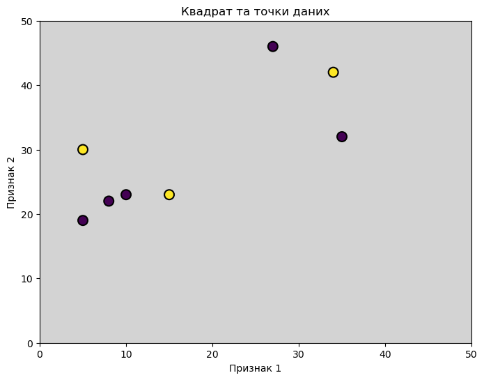

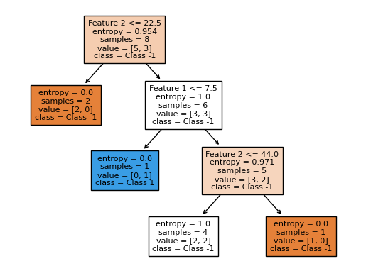

```
Annotation(0.333333, 0.875, 'Feature 2 <= 22.5\nentropy = 0.954\nsamples = 8\nvalue = [5, 3]\nclass = Class -1')
```

```python
import numpy as np
import matplotlib.pyplot as plt
from sklearn.tree import DecisionTreeClassifier, plot_tree

# Ваши дані
x_train_5 = np.array([[27, 46], [8, 22], [5, 30], [5, 19], [15, 23], [34, 42], [10, 23], [35, 32]])
y_train_5 = np.array([-1, -1, 1, -1, 1, 1, -1, -1])

# Побудова квадрата та точок
plt.figure(figsize=(8, 6))
plt.xlim(0, 50)
plt.ylim(0, 50)
plt.fill_between([0, 50], 0, 50, color='lightgray')
plt.scatter(x_train_5[:, 0], x_train_5[:, 1], c=y_train_5, cmap='viridis', s=100, edgecolors='black', linewidth=1.5)
plt.title('Квадрат та точки даних')
plt.xlabel('Признак 1')
plt.ylabel('Признак 2')
plt.show()

# Ініціалізація та навчання моделі дерева ухвалення рішень
clf_tree = DecisionTreeClassifier(criterion='entropy', max_depth=3, random_state=5)
clf_tree.fit(x_train_5, y_train_5)

# Виведення структури дерева ухвалення рішень
tree_structure = plot_tree(clf_tree, filled=True, feature_names=['Feature 1', 'Feature 2'], class_names=['Class -1', 'Class 1'], fontsize=8)
plt.show()

# Виведення текстового представлення дерева ухвалення рішень
text_representation = tree_structure[0]
print(text_representation)
```

# Контрольні запитання

1.У чому полягає задача кластеризації та які її цілі?

**Кластеризація полягає в групуванні схожих об'єктів у колекції. Мета полягає в тому, щоб об'єкти всередині одного кластера були якомога більш схожими між собою, а об'єкти між різними кластерами були якомога менш схожими. Основні цілі кластеризації включають в себе виявлення природних груп об'єктів у даних, розуміння структури даних та спрощення подальшого аналізу даних.**  
2.Які критерії використовуються для оцінки якості розбиття об’єктів на групи у задачі кластеризації?  
**Критерії, які використовуються для оцінки якості кластеризації, можуть включати метрики внутрішнього та зовнішнього зв'язку. Деякі популярні метрики включають індекс силуету, додаткову дисперсію, кількість кластерів, довжину периметра та інші.**  
3.Що таке задача часткового навчання в контексті кластеризації? У чому полягаєЯка ідея алгоритму k-середніх (k-means)? У чому полягаєновна ідея алгоритму DBSCANn.  
Задача часткового навчання в контексті кластеризації: Задача часткового навчання виникає, коли доступні лише деякі мітки класів для обмеженого підмножини даних. У контексті кластеризації це може означати, що ми маємо деякі мітки класів для об'єктів у деяких кластерах, але інші об'єкти можуть бути непозначеними. Мета полягає в тому, щоб використовувати ці обмежені мітки класів для навчання моделі кластеризації, щоб покращити якість розбиття.  
Алгоритм k-середніх (k-means): Ключова ідея алгоритму k-середніх полягає в тому, щоб згрупувати об'єкти в k кластерів, мінімізуючи середній квадрат відстаней між кожним об'єктом і центром його кластера.  
Алгоритм DBSCAN: DBSCAN (Density-Based Spatial Clustering of Applications with Noise) — це алгоритм кластеризації, який групує об'єкти у кластери на основі їх густини в просторі ознак. Основна ідея полягає в тому, щоб виявити області в просторі даних з високою густиністю, які відповідають кластерам, і розділити області з низькою густиністю або окремі точки як шум.  
4.Як можна скористатися засобами бібліотеки scikit-learn для реалізації алгоритму DBSCAN на Python?  
**Реалізація алгоритму DBSCAN за допомогою scikit-learn: Можна використати модуль sklearn.cluster.DBSCAN для реалізації алгоритму DBSCAN в Python засобами бібліотеки scikit-learn. Це дає можливість використовувати різні параметри, такі як радіус епсилон і мінімальна кількість сусідів, для налаштування алгоритму залежно від конкретних потреб.**